# Risk Factor Analysis

## Outcome Variable

**Outcome Variable:** ever_wasted

## Predictor Variables

**Intervention Variable:** hdlvry

**Adjustment Set:**

- arm
- sex
- W_mage
- meducyrs
- feducyrs
- hhwealth_quart
- single
- W_nrooms
- brthmon
- W_parity
- impsan
- delta_W_mage
- delta_meducyrs
- delta_feducyrs
- delta_hhwealth_quart
- delta_single
- delta_W_nrooms
- delta_brthmon
- delta_W_parity
- delta_impsan

## Stratifying Variables

The analysis was stratified on these variable(s):

- agecat
- studyid
- country

## Data Summary

| agecat | studyid | country | hdlvry | ever_wasted | n_cell | n |
| --- | --- | --- | --- | --- | --- | --- |
| 0-24 months (no birth wast) | CMC-V-BCS-2002 | INDIA | 0 | 0 | 196 | 365 |
| 0-24 months (no birth wast) | CMC-V-BCS-2002 | INDIA | 0 | 1 | 161 | 365 |
| 0-24 months (no birth wast) | CMC-V-BCS-2002 | INDIA | 1 | 0 | 5 | 365 |
| 0-24 months (no birth wast) | CMC-V-BCS-2002 | INDIA | 1 | 1 | 3 | 365 |
| 0-24 months (no birth wast) | COHORTS | INDIA | 0 | 0 | 2513 | 4904 |
| 0-24 months (no birth wast) | COHORTS | INDIA | 0 | 1 | 517 | 4904 |
| 0-24 months (no birth wast) | COHORTS | INDIA | 1 | 0 | 1423 | 4904 |
| 0-24 months (no birth wast) | COHORTS | INDIA | 1 | 1 | 451 | 4904 |
| 0-24 months (no birth wast) | EE | PAKISTAN | 0 | 0 | 117 | 375 |
| 0-24 months (no birth wast) | EE | PAKISTAN | 0 | 1 | 135 | 375 |
| 0-24 months (no birth wast) | EE | PAKISTAN | 1 | 0 | 56 | 375 |
| 0-24 months (no birth wast) | EE | PAKISTAN | 1 | 1 | 67 | 375 |
| 0-24 months (no birth wast) | GMS-Nepal | NEPAL | 0 | 0 | 83 | 613 |
| 0-24 months (no birth wast) | GMS-Nepal | NEPAL | 0 | 1 | 65 | 613 |
| 0-24 months (no birth wast) | GMS-Nepal | NEPAL | 1 | 0 | 221 | 613 |
| 0-24 months (no birth wast) | GMS-Nepal | NEPAL | 1 | 1 | 244 | 613 |
| 0-24 months (no birth wast) | IRC | INDIA | 0 | 0 | 190 | 409 |
| 0-24 months (no birth wast) | IRC | INDIA | 0 | 1 | 211 | 409 |
| 0-24 months (no birth wast) | IRC | INDIA | 1 | 0 | 6 | 409 |
| 0-24 months (no birth wast) | IRC | INDIA | 1 | 1 | 2 | 409 |
| 0-24 months (no birth wast) | JiVitA-3 | BANGLADESH | 0 | 0 | 34 | 346 |
| 0-24 months (no birth wast) | JiVitA-3 | BANGLADESH | 0 | 1 | 7 | 346 |
| 0-24 months (no birth wast) | JiVitA-3 | BANGLADESH | 1 | 0 | 236 | 346 |
| 0-24 months (no birth wast) | JiVitA-3 | BANGLADESH | 1 | 1 | 69 | 346 |
| 0-24 months (no birth wast) | JiVitA-4 | BANGLADESH | 0 | 0 | 888 | 4480 |
| 0-24 months (no birth wast) | JiVitA-4 | BANGLADESH | 0 | 1 | 279 | 4480 |
| 0-24 months (no birth wast) | JiVitA-4 | BANGLADESH | 1 | 0 | 2398 | 4480 |
| 0-24 months (no birth wast) | JiVitA-4 | BANGLADESH | 1 | 1 | 915 | 4480 |
| 0-24 months (no birth wast) | NIH-Crypto | BANGLADESH | 0 | 0 | 513 | 754 |
| 0-24 months (no birth wast) | NIH-Crypto | BANGLADESH | 0 | 1 | 74 | 754 |

[output cut: 114 more lines]

The following strata were considered:

- agecat: 0-24 months (no birth wast), studyid: CMC-V-BCS-2002, country: INDIA
- agecat: 0-24 months (no birth wast), studyid: COHORTS, country: INDIA
- agecat: 0-24 months (no birth wast), studyid: EE, country: PAKISTAN
- agecat: 0-24 months (no birth wast), studyid: GMS-Nepal, country: NEPAL
- agecat: 0-24 months (no birth wast), studyid: IRC, country: INDIA
- agecat: 0-24 months (no birth wast), studyid: JiVitA-3, country: BANGLADESH
- agecat: 0-24 months (no birth wast), studyid: JiVitA-4, country: BANGLADESH
- agecat: 0-24 months (no birth wast), studyid: NIH-Crypto, country: BANGLADESH
- agecat: 0-24 months (no birth wast), studyid: PROVIDE, country: BANGLADESH
- agecat: 0-24 months (no birth wast), studyid: SAS-CompFeed, country: INDIA
- agecat: 0-24 months (no birth wast), studyid: SAS-FoodSuppl, country: INDIA
- agecat: 0-24 months (no birth wast), studyid: TanzaniaChild2, country: TANZANIA, UNITED REPUBLIC OF
- agecat: 0-6 months (no birth wast), studyid: CMC-V-BCS-2002, country: INDIA
- agecat: 0-6 months (no birth wast), studyid: COHORTS, country: INDIA
- agecat: 0-6 months (no birth wast), studyid: EE, country: PAKISTAN
- agecat: 0-6 months (no birth wast), studyid: GMS-Nepal, country: NEPAL
- agecat: 0-6 months (no birth wast), studyid: IRC, country: INDIA
- agecat: 0-6 months (no birth wast), studyid: JiVitA-3, country: BANGLADESH
- agecat: 0-6 months (no birth wast), studyid: JiVitA-4, country: BANGLADESH
- agecat: 0-6 months (no birth wast), studyid: NIH-Crypto, country: BANGLADESH
- agecat: 0-6 months (no birth wast), studyid: PROVIDE, country: BANGLADESH
- agecat: 0-6 months (no birth wast), studyid: SAS-CompFeed, country: INDIA
- agecat: 0-6 months (no birth wast), studyid: SAS-FoodSuppl, country: INDIA
- agecat: 0-6 months (no birth wast), studyid: TanzaniaChild2, country: TANZANIA, UNITED REPUBLIC OF
- agecat: 6-24 months, studyid: CMC-V-BCS-2002, country: INDIA
- agecat: 6-24 months, studyid: COHORTS, country: INDIA
- agecat: 6-24 months, studyid: EE, country: PAKISTAN
- agecat: 6-24 months, studyid: GMS-Nepal, country: NEPAL
- agecat: 6-24 months, studyid: IRC, country: INDIA
- agecat: 6-24 months, studyid: JiVitA-3, country: BANGLADESH
- agecat: 6-24 months, studyid: JiVitA-4, country: BANGLADESH
- agecat: 6-24 months, studyid: NIH-Crypto, country: BANGLADESH
- agecat: 6-24 months, studyid: PROVIDE, country: BANGLADESH
- agecat: 6-24 months, studyid: SAS-CompFeed, country: INDIA
- agecat: 6-24 months, studyid: SAS-FoodSuppl, country: INDIA
- agecat: 6-24 months, studyid: TanzaniaChild2, country: TANZANIA, UNITED REPUBLIC OF

### Dropped Strata

Some strata were dropped due to rare outcomes:

- agecat: 0-24 months (no birth wast), studyid: CMC-V-BCS-2002, country: INDIA
- agecat: 0-24 months (no birth wast), studyid: IRC, country: INDIA
- agecat: 0-6 months (no birth wast), studyid: CMC-V-BCS-2002, country: INDIA
- agecat: 0-6 months (no birth wast), studyid: IRC, country: INDIA
- agecat: 0-6 months (no birth wast), studyid: SAS-FoodSuppl, country: INDIA
- agecat: 0-6 months (no birth wast), studyid: TanzaniaChild2, country: TANZANIA, UNITED REPUBLIC OF
- agecat: 6-24 months, studyid: CMC-V-BCS-2002, country: INDIA
- agecat: 6-24 months, studyid: IRC, country: INDIA
- agecat: 6-24 months, studyid: JiVitA-3, country: BANGLADESH
- agecat: 6-24 months, studyid: TanzaniaChild2, country: TANZANIA, UNITED REPUBLIC OF

## Methods Detail

We’re interested in the causal parameters $E[Y_a]$ for all values of $a \in \mathcal{A}$. These parameters represent the mean outcome if, possibly contrary to fact, we intervened to set all units to have $A=a$. Under the randomization and positivity assumptions, these are identified by the statistical parameters $\psi_a=E_W[E_{Y|A,W}(Y|A=a,W)]$. In addition, we’re interested in the mean of $Y$, $E[Y]$ under no intervention (the observed mean). We will estimate these parameters by using SuperLearner to fit the relevant likelihood factors – $E_{Y|A,W}(Y|A=a,W)$ and $p(A=a|W)$, and then updating our likelihood fit using a joint TMLE.

For unadjusted analyses ($W=\{\}$), initial likelihoods were estimated using Lrnr_glm to estimate the simple $E(Y|A)$ and Lrnr_mean to estimate $p(A)$. For adjusted analyses, a small library containing Lrnr_glmnet, Lrnr_xgboost, and Lrnr_mean was used.

Having estimated these parameters, we will then use the delta method to estimate relative risks and attributable risks relative to a prespecified baseline level of $A$.

# Results Detail

## Results Plots

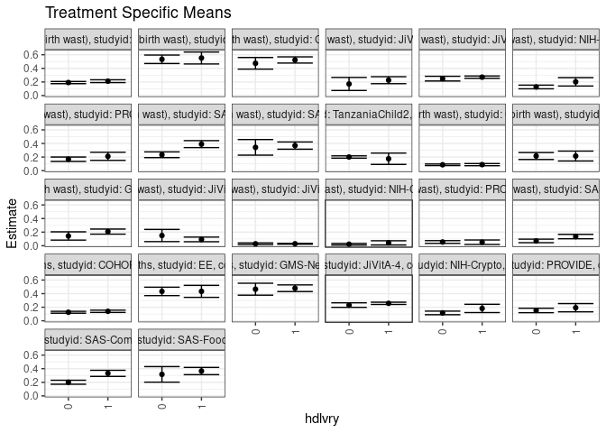

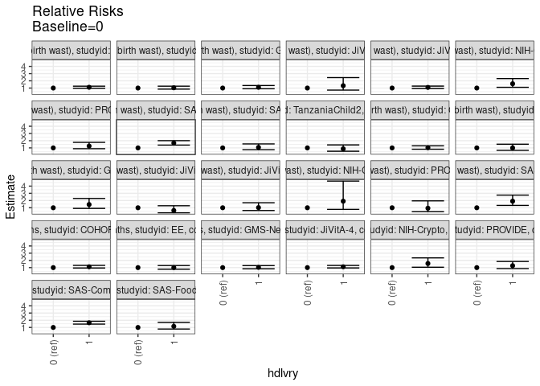

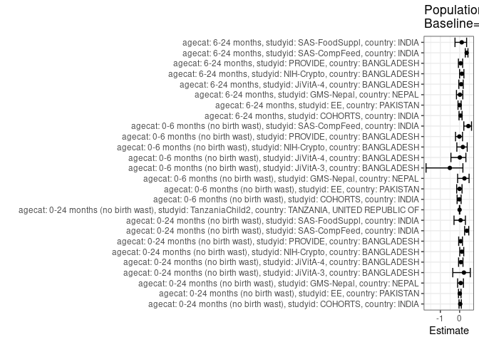

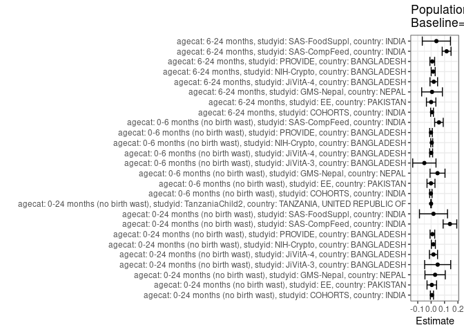

## Results Table

### Parameter: TSM

| agecat | studyid | country | intervention_level | baseline_level | estimate | ci_lower | ci_upper |
| --- | --- | --- | --- | --- | --- | --- | --- |
| 0-24 months (no birth wast) | COHORTS | INDIA | 0 | NA | 0.1914510 | 0.1753837 | 0.2075184 |
| 0-24 months (no birth wast) | COHORTS | INDIA | 1 | NA | 0.2116358 | 0.1907631 | 0.2325084 |
| 0-24 months (no birth wast) | EE | PAKISTAN | 0 | NA | 0.5336534 | 0.4715765 | 0.5957303 |
| 0-24 months (no birth wast) | EE | PAKISTAN | 1 | NA | 0.5525912 | 0.4648007 | 0.6403817 |
| 0-24 months (no birth wast) | GMS-Nepal | NEPAL | 0 | NA | 0.4743421 | 0.3886688 | 0.5600154 |
| 0-24 months (no birth wast) | GMS-Nepal | NEPAL | 1 | NA | 0.5237052 | 0.4781426 | 0.5692678 |
| 0-24 months (no birth wast) | JiVitA-3 | BANGLADESH | 0 | NA | 0.1707317 | 0.0749030 | 0.2665604 |
| 0-24 months (no birth wast) | JiVitA-3 | BANGLADESH | 1 | NA | 0.2262295 | 0.1750012 | 0.2774578 |
| 0-24 months (no birth wast) | JiVitA-4 | BANGLADESH | 0 | NA | 0.2487509 | 0.2141440 | 0.2833578 |
| 0-24 months (no birth wast) | JiVitA-4 | BANGLADESH | 1 | NA | 0.2708155 | 0.2538342 | 0.2877968 |
| 0-24 months (no birth wast) | NIH-Crypto | BANGLADESH | 0 | NA | 0.1266490 | 0.0997634 | 0.1535346 |
| 0-24 months (no birth wast) | NIH-Crypto | BANGLADESH | 1 | NA | 0.2021490 | 0.1405121 | 0.2637858 |
| 0-24 months (no birth wast) | PROVIDE | BANGLADESH | 0 | NA | 0.1680837 | 0.1357213 | 0.2004460 |
| 0-24 months (no birth wast) | PROVIDE | BANGLADESH | 1 | NA | 0.2109785 | 0.1510517 | 0.2709052 |
| 0-24 months (no birth wast) | SAS-CompFeed | INDIA | 0 | NA | 0.2337761 | 0.1914423 | 0.2761099 |
| 0-24 months (no birth wast) | SAS-CompFeed | INDIA | 1 | NA | 0.3901391 | 0.3388881 | 0.4413901 |
| 0-24 months (no birth wast) | SAS-FoodSuppl | INDIA | 0 | NA | 0.3425087 | 0.2277427 | 0.4572747 |
| 0-24 months (no birth wast) | SAS-FoodSuppl | INDIA | 1 | NA | 0.3685479 | 0.3153816 | 0.4217141 |
| 0-24 months (no birth wast) | TanzaniaChild2 | TANZANIA, UNITED REPUBLIC OF | 0 | NA | 0.2007201 | 0.1839373 | 0.2175028 |
| 0-24 months (no birth wast) | TanzaniaChild2 | TANZANIA, UNITED REPUBLIC OF | 1 | NA | 0.1750000 | 0.0916918 | 0.2583082 |
| 0-6 months (no birth wast) | COHORTS | INDIA | 0 | NA | 0.0864426 | 0.0743571 | 0.0985281 |
| 0-6 months (no birth wast) | COHORTS | INDIA | 1 | NA | 0.0886023 | 0.0727388 | 0.1044657 |
| 0-6 months (no birth wast) | EE | PAKISTAN | 0 | NA | 0.2154909 | 0.1641482 | 0.2668336 |
| 0-6 months (no birth wast) | EE | PAKISTAN | 1 | NA | 0.2148871 | 0.1420205 | 0.2877536 |
| 0-6 months (no birth wast) | GMS-Nepal | NEPAL | 0 | NA | 0.1435504 | 0.0828030 | 0.2042978 |
| 0-6 months (no birth wast) | GMS-Nepal | NEPAL | 1 | NA | 0.2075483 | 0.1701198 | 0.2449769 |
| 0-6 months (no birth wast) | JiVitA-3 | BANGLADESH | 0 | NA | 0.1500000 | 0.0603230 | 0.2396770 |
| 0-6 months (no birth wast) | JiVitA-3 | BANGLADESH | 1 | NA | 0.0927152 | 0.0586870 | 0.1267434 |
| 0-6 months (no birth wast) | JiVitA-4 | BANGLADESH | 0 | NA | 0.0283648 | 0.0154883 | 0.0412412 |
| 0-6 months (no birth wast) | JiVitA-4 | BANGLADESH | 1 | NA | 0.0290202 | 0.0230962 | 0.0349442 |
| 0-6 months (no birth wast) | NIH-Crypto | BANGLADESH | 0 | NA | 0.0222603 | 0.0102871 | 0.0342334 |
| 0-6 months (no birth wast) | NIH-Crypto | BANGLADESH | 1 | NA | 0.0424242 | 0.0116498 | 0.0731987 |
| 0-6 months (no birth wast) | PROVIDE | BANGLADESH | 0 | NA | 0.0550098 | 0.0351881 | 0.0748315 |
| 0-6 months (no birth wast) | PROVIDE | BANGLADESH | 1 | NA | 0.0517241 | 0.0187931 | 0.0846552 |
| 0-6 months (no birth wast) | SAS-CompFeed | INDIA | 0 | NA | 0.0706315 | 0.0446041 | 0.0966589 |
| 0-6 months (no birth wast) | SAS-CompFeed | INDIA | 1 | NA | 0.1348622 | 0.1024239 | 0.1673005 |
| 6-24 months | COHORTS | INDIA | 0 | NA | 0.1259912 | 0.1120059 | 0.1399765 |
| 6-24 months | COHORTS | INDIA | 1 | NA | 0.1399408 | 0.1231382 | 0.1567434 |
| 6-24 months | EE | PAKISTAN | 0 | NA | 0.4325582 | 0.3708691 | 0.4942472 |
| 6-24 months | EE | PAKISTAN | 1 | NA | 0.4332918 | 0.3452396 | 0.5213441 |
| 6-24 months | GMS-Nepal | NEPAL | 0 | NA | 0.4649403 | 0.3772326 | 0.5526479 |
| 6-24 months | GMS-Nepal | NEPAL | 1 | NA | 0.4793863 | 0.4304933 | 0.5282793 |
| 6-24 months | JiVitA-4 | BANGLADESH | 0 | NA | 0.2313220 | 0.1982501 | 0.2643939 |
| 6-24 months | JiVitA-4 | BANGLADESH | 1 | NA | 0.2571875 | 0.2405297 | 0.2738453 |
| 6-24 months | NIH-Crypto | BANGLADESH | 0 | NA | 0.1161263 | 0.0897726 | 0.1424801 |
| 6-24 months | NIH-Crypto | BANGLADESH | 1 | NA | 0.1821592 | 0.1214456 | 0.2428729 |
| 6-24 months | PROVIDE | BANGLADESH | 0 | NA | 0.1523533 | 0.1196063 | 0.1851003 |
| 6-24 months | PROVIDE | BANGLADESH | 1 | NA | 0.1927287 | 0.1320452 | 0.2534122 |
| 6-24 months | SAS-CompFeed | INDIA | 0 | NA | 0.2008907 | 0.1715221 | 0.2302594 |
| 6-24 months | SAS-CompFeed | INDIA | 1 | NA | 0.3314853 | 0.2866730 | 0.3762976 |
| 6-24 months | SAS-FoodSuppl | INDIA | 0 | NA | 0.3164524 | 0.2022790 | 0.4306259 |
| 6-24 months | SAS-FoodSuppl | INDIA | 1 | NA | 0.3656735 | 0.3122675 | 0.4190795 |

### Parameter: E(Y)

| agecat | studyid | country | intervention_level | baseline_level | estimate | ci_lower | ci_upper |
| --- | --- | --- | --- | --- | --- | --- | --- |
| 0-24 months (no birth wast) | COHORTS | INDIA | NA | NA | 0.1973899 | 0.1862487 | 0.2085311 |
| 0-24 months (no birth wast) | EE | PAKISTAN | NA | NA | 0.5386667 | 0.4881448 | 0.5891886 |
| 0-24 months (no birth wast) | GMS-Nepal | NEPAL | NA | NA | 0.5040783 | 0.4644662 | 0.5436904 |
| 0-24 months (no birth wast) | JiVitA-3 | BANGLADESH | NA | NA | 0.2196532 | 0.1732957 | 0.2660107 |
| 0-24 months (no birth wast) | JiVitA-4 | BANGLADESH | NA | NA | 0.2665179 | 0.2514258 | 0.2816100 |
| 0-24 months (no birth wast) | NIH-Crypto | BANGLADESH | NA | NA | 0.1432361 | 0.1182149 | 0.1682572 |
| 0-24 months (no birth wast) | PROVIDE | BANGLADESH | NA | NA | 0.1775837 | 0.1489858 | 0.2061816 |
| 0-24 months (no birth wast) | SAS-CompFeed | INDIA | NA | NA | 0.3741830 | 0.3195305 | 0.4288355 |
| 0-24 months (no birth wast) | SAS-FoodSuppl | INDIA | NA | NA | 0.3602015 | 0.3129196 | 0.4074834 |
| 0-24 months (no birth wast) | TanzaniaChild2 | TANZANIA, UNITED REPUBLIC OF | NA | NA | 0.2002653 | 0.1837694 | 0.2167611 |
| 0-6 months (no birth wast) | COHORTS | INDIA | NA | NA | 0.0846222 | 0.0765129 | 0.0927314 |
| 0-6 months (no birth wast) | EE | PAKISTAN | NA | NA | 0.2144772 | 0.1727666 | 0.2561878 |
| 0-6 months (no birth wast) | GMS-Nepal | NEPAL | NA | NA | 0.1912752 | 0.1596728 | 0.2228775 |
| 0-6 months (no birth wast) | JiVitA-3 | BANGLADESH | NA | NA | 0.0994152 | 0.0685873 | 0.1302431 |
| 0-6 months (no birth wast) | JiVitA-4 | BANGLADESH | NA | NA | 0.0286500 | 0.0232922 | 0.0340079 |
| 0-6 months (no birth wast) | NIH-Crypto | BANGLADESH | NA | NA | 0.0267023 | 0.0151493 | 0.0382553 |
| 0-6 months (no birth wast) | PROVIDE | BANGLADESH | NA | NA | 0.0541728 | 0.0371844 | 0.0711612 |
| 0-6 months (no birth wast) | SAS-CompFeed | INDIA | NA | NA | 0.1289517 | 0.0982960 | 0.1596075 |
| 6-24 months | COHORTS | INDIA | NA | NA | 0.1326445 | 0.1229894 | 0.1422995 |
| 6-24 months | EE | PAKISTAN | NA | NA | 0.4327957 | 0.3823792 | 0.4832122 |
| 6-24 months | GMS-Nepal | NEPAL | NA | NA | 0.4717668 | 0.4299709 | 0.5135628 |
| 6-24 months | JiVitA-4 | BANGLADESH | NA | NA | 0.2511131 | 0.2362659 | 0.2659603 |
| 6-24 months | NIH-Crypto | BANGLADESH | NA | NA | 0.1315068 | 0.1069744 | 0.1560393 |
| 6-24 months | PROVIDE | BANGLADESH | NA | NA | 0.1609756 | 0.1319065 | 0.1900447 |
| 6-24 months | SAS-CompFeed | INDIA | NA | NA | 0.3164894 | 0.2686679 | 0.3643108 |
| 6-24 months | SAS-FoodSuppl | INDIA | NA | NA | 0.3557214 | 0.3088651 | 0.4025777 |

### Parameter: RR

| agecat | studyid | country | intervention_level | baseline_level | estimate | ci_lower | ci_upper |
| --- | --- | --- | --- | --- | --- | --- | --- |
| 0-24 months (no birth wast) | COHORTS | INDIA | 0 | 0 | 1.0000000 | 1.0000000 | 1.000000 |
| 0-24 months (no birth wast) | COHORTS | INDIA | 1 | 0 | 1.1054302 | 0.9716841 | 1.257586 |
| 0-24 months (no birth wast) | EE | PAKISTAN | 0 | 0 | 1.0000000 | 1.0000000 | 1.000000 |
| 0-24 months (no birth wast) | EE | PAKISTAN | 1 | 0 | 1.0354872 | 0.8507261 | 1.260375 |
| 0-24 months (no birth wast) | GMS-Nepal | NEPAL | 0 | 0 | 1.0000000 | 1.0000000 | 1.000000 |
| 0-24 months (no birth wast) | GMS-Nepal | NEPAL | 1 | 0 | 1.1040665 | 0.9034230 | 1.349271 |
| 0-24 months (no birth wast) | JiVitA-3 | BANGLADESH | 0 | 0 | 1.0000000 | 1.0000000 | 1.000000 |
| 0-24 months (no birth wast) | JiVitA-3 | BANGLADESH | 1 | 0 | 1.3250585 | 0.7169637 | 2.448911 |
| 0-24 months (no birth wast) | JiVitA-4 | BANGLADESH | 0 | 0 | 1.0000000 | 1.0000000 | 1.000000 |
| 0-24 months (no birth wast) | JiVitA-4 | BANGLADESH | 1 | 0 | 1.0887014 | 0.9344227 | 1.268452 |
| 0-24 months (no birth wast) | NIH-Crypto | BANGLADESH | 0 | 0 | 1.0000000 | 1.0000000 | 1.000000 |
| 0-24 months (no birth wast) | NIH-Crypto | BANGLADESH | 1 | 0 | 1.5961356 | 1.1006167 | 2.314747 |
| 0-24 months (no birth wast) | PROVIDE | BANGLADESH | 0 | 0 | 1.0000000 | 1.0000000 | 1.000000 |
| 0-24 months (no birth wast) | PROVIDE | BANGLADESH | 1 | 0 | 1.2551988 | 0.8908066 | 1.768649 |
| 0-24 months (no birth wast) | SAS-CompFeed | INDIA | 0 | 0 | 1.0000000 | 1.0000000 | 1.000000 |
| 0-24 months (no birth wast) | SAS-CompFeed | INDIA | 1 | 0 | 1.6688580 | 1.3878128 | 2.006817 |
| 0-24 months (no birth wast) | SAS-FoodSuppl | INDIA | 0 | 0 | 1.0000000 | 1.0000000 | 1.000000 |
| 0-24 months (no birth wast) | SAS-FoodSuppl | INDIA | 1 | 0 | 1.0760249 | 0.7468317 | 1.550322 |
| 0-24 months (no birth wast) | TanzaniaChild2 | TANZANIA, UNITED REPUBLIC OF | 0 | 0 | 1.0000000 | 1.0000000 | 1.000000 |
| 0-24 months (no birth wast) | TanzaniaChild2 | TANZANIA, UNITED REPUBLIC OF | 1 | 0 | 0.8718610 | 0.5376976 | 1.413697 |
| 0-6 months (no birth wast) | COHORTS | INDIA | 0 | 0 | 1.0000000 | 1.0000000 | 1.000000 |
| 0-6 months (no birth wast) | COHORTS | INDIA | 1 | 0 | 1.0249837 | 0.8166740 | 1.286427 |
| 0-6 months (no birth wast) | EE | PAKISTAN | 0 | 0 | 1.0000000 | 1.0000000 | 1.000000 |
| 0-6 months (no birth wast) | EE | PAKISTAN | 1 | 0 | 0.9971977 | 0.6577914 | 1.511730 |
| 0-6 months (no birth wast) | GMS-Nepal | NEPAL | 0 | 0 | 1.0000000 | 1.0000000 | 1.000000 |
| 0-6 months (no birth wast) | GMS-Nepal | NEPAL | 1 | 0 | 1.4458220 | 0.9125595 | 2.290701 |
| 0-6 months (no birth wast) | JiVitA-3 | BANGLADESH | 0 | 0 | 1.0000000 | 1.0000000 | 1.000000 |
| 0-6 months (no birth wast) | JiVitA-3 | BANGLADESH | 1 | 0 | 0.6181015 | 0.2989442 | 1.277996 |
| 0-6 months (no birth wast) | JiVitA-4 | BANGLADESH | 0 | 0 | 1.0000000 | 1.0000000 | 1.000000 |
| 0-6 months (no birth wast) | JiVitA-4 | BANGLADESH | 1 | 0 | 1.0231073 | 0.6168746 | 1.696858 |
| 0-6 months (no birth wast) | NIH-Crypto | BANGLADESH | 0 | 0 | 1.0000000 | 1.0000000 | 1.000000 |
| 0-6 months (no birth wast) | NIH-Crypto | BANGLADESH | 1 | 0 | 1.9058275 | 0.7724891 | 4.701916 |
| 0-6 months (no birth wast) | PROVIDE | BANGLADESH | 0 | 0 | 1.0000000 | 1.0000000 | 1.000000 |
| 0-6 months (no birth wast) | PROVIDE | BANGLADESH | 1 | 0 | 0.9402709 | 0.4524178 | 1.954188 |
| 0-6 months (no birth wast) | SAS-CompFeed | INDIA | 0 | 0 | 1.0000000 | 1.0000000 | 1.000000 |
| 0-6 months (no birth wast) | SAS-CompFeed | INDIA | 1 | 0 | 1.9093779 | 1.3249110 | 2.751675 |
| 6-24 months | COHORTS | INDIA | 0 | 0 | 1.0000000 | 1.0000000 | 1.000000 |
| 6-24 months | COHORTS | INDIA | 1 | 0 | 1.1107188 | 0.9440522 | 1.306809 |
| 6-24 months | EE | PAKISTAN | 0 | 0 | 1.0000000 | 1.0000000 | 1.000000 |
| 6-24 months | EE | PAKISTAN | 1 | 0 | 1.0016961 | 0.7816744 | 1.283648 |
| 6-24 months | GMS-Nepal | NEPAL | 0 | 0 | 1.0000000 | 1.0000000 | 1.000000 |
| 6-24 months | GMS-Nepal | NEPAL | 1 | 0 | 1.0310707 | 0.8322305 | 1.277419 |
| 6-24 months | JiVitA-4 | BANGLADESH | 0 | 0 | 1.0000000 | 1.0000000 | 1.000000 |
| 6-24 months | JiVitA-4 | BANGLADESH | 1 | 0 | 1.1118158 | 0.9515107 | 1.299128 |
| 6-24 months | NIH-Crypto | BANGLADESH | 0 | 0 | 1.0000000 | 1.0000000 | 1.000000 |
| 6-24 months | NIH-Crypto | BANGLADESH | 1 | 0 | 1.5686300 | 1.0480823 | 2.347716 |
| 6-24 months | PROVIDE | BANGLADESH | 0 | 0 | 1.0000000 | 1.0000000 | 1.000000 |
| 6-24 months | PROVIDE | BANGLADESH | 1 | 0 | 1.2650116 | 0.8654502 | 1.849043 |
| 6-24 months | SAS-CompFeed | INDIA | 0 | 0 | 1.0000000 | 1.0000000 | 1.000000 |
| 6-24 months | SAS-CompFeed | INDIA | 1 | 0 | 1.6500774 | 1.4640688 | 1.859718 |
| 6-24 months | SAS-FoodSuppl | INDIA | 0 | 0 | 1.0000000 | 1.0000000 | 1.000000 |
| 6-24 months | SAS-FoodSuppl | INDIA | 1 | 0 | 1.1555401 | 0.7828175 | 1.705727 |

### Parameter: PAR

| agecat | studyid | country | intervention_level | baseline_level | estimate | ci_lower | ci_upper |
| --- | --- | --- | --- | --- | --- | --- | --- |
| 0-24 months (no birth wast) | COHORTS | INDIA | 0 | NA | 0.0059388 | -0.0058232 | 0.0177009 |
| 0-24 months (no birth wast) | EE | PAKISTAN | 0 | NA | 0.0050133 | -0.0306292 | 0.0406558 |
| 0-24 months (no birth wast) | GMS-Nepal | NEPAL | 0 | NA | 0.0297362 | -0.0461824 | 0.1056548 |
| 0-24 months (no birth wast) | JiVitA-3 | BANGLADESH | 0 | NA | 0.0489215 | -0.0484409 | 0.1462839 |
| 0-24 months (no birth wast) | JiVitA-4 | BANGLADESH | 0 | NA | 0.0177669 | -0.0123598 | 0.0478937 |
| 0-24 months (no birth wast) | NIH-Crypto | BANGLADESH | 0 | NA | 0.0165871 | 0.0016077 | 0.0315665 |
| 0-24 months (no birth wast) | PROVIDE | BANGLADESH | 0 | NA | 0.0095000 | -0.0078166 | 0.0268166 |
| 0-24 months (no birth wast) | SAS-CompFeed | INDIA | 0 | NA | 0.1404069 | 0.0895219 | 0.1912919 |
| 0-24 months (no birth wast) | SAS-FoodSuppl | INDIA | 0 | NA | 0.0176928 | -0.0870772 | 0.1224628 |
| 0-24 months (no birth wast) | TanzaniaChild2 | TANZANIA, UNITED REPUBLIC OF | 0 | NA | -0.0004548 | -0.0025840 | 0.0016743 |
| 0-6 months (no birth wast) | COHORTS | INDIA | 0 | NA | -0.0018204 | -0.0105666 | 0.0069258 |
| 0-6 months (no birth wast) | EE | PAKISTAN | 0 | NA | -0.0010137 | -0.0307474 | 0.0287200 |
| 0-6 months (no birth wast) | GMS-Nepal | NEPAL | 0 | NA | 0.0477248 | -0.0081506 | 0.1036002 |
| 0-6 months (no birth wast) | JiVitA-3 | BANGLADESH | 0 | NA | -0.0505848 | -0.1374669 | 0.0362973 |
| 0-6 months (no birth wast) | JiVitA-4 | BANGLADESH | 0 | NA | 0.0002852 | -0.0105477 | 0.0111182 |
| 0-6 months (no birth wast) | NIH-Crypto | BANGLADESH | 0 | NA | 0.0044420 | -0.0028570 | 0.0117410 |
| 0-6 months (no birth wast) | PROVIDE | BANGLADESH | 0 | NA | -0.0008371 | -0.0106296 | 0.0089555 |
| 0-6 months (no birth wast) | SAS-CompFeed | INDIA | 0 | NA | 0.0583203 | 0.0263022 | 0.0903383 |
| 6-24 months | COHORTS | INDIA | 0 | NA | 0.0066532 | -0.0037645 | 0.0170710 |
| 6-24 months | EE | PAKISTAN | 0 | NA | 0.0002375 | -0.0350237 | 0.0354988 |
| 6-24 months | GMS-Nepal | NEPAL | 0 | NA | 0.0068266 | -0.0704416 | 0.0840948 |
| 6-24 months | JiVitA-4 | BANGLADESH | 0 | NA | 0.0197911 | -0.0086168 | 0.0481990 |
| 6-24 months | NIH-Crypto | BANGLADESH | 0 | NA | 0.0153805 | 0.0004755 | 0.0302855 |
| 6-24 months | PROVIDE | BANGLADESH | 0 | NA | 0.0086223 | -0.0090246 | 0.0262692 |
| 6-24 months | SAS-CompFeed | INDIA | 0 | NA | 0.1155986 | 0.0825131 | 0.1486841 |
| 6-24 months | SAS-FoodSuppl | INDIA | 0 | NA | 0.0392690 | -0.0659445 | 0.1444824 |

### Parameter: PAF

| agecat | studyid | country | intervention_level | baseline_level | estimate | ci_lower | ci_upper |
| --- | --- | --- | --- | --- | --- | --- | --- |
| 0-24 months (no birth wast) | COHORTS | INDIA | 0 | NA | 0.0300869 | -0.0313654 | 0.0878776 |
| 0-24 months (no birth wast) | EE | PAKISTAN | 0 | NA | 0.0093069 | -0.0591350 | 0.0733260 |
| 0-24 months (no birth wast) | GMS-Nepal | NEPAL | 0 | NA | 0.0589912 | -0.1044298 | 0.1982311 |
| 0-24 months (no birth wast) | JiVitA-3 | BANGLADESH | 0 | NA | 0.2227214 | -0.3565950 | 0.5546483 |
| 0-24 months (no birth wast) | JiVitA-4 | BANGLADESH | 0 | NA | 0.0666631 | -0.0538676 | 0.1734088 |
| 0-24 months (no birth wast) | NIH-Crypto | BANGLADESH | 0 | NA | 0.1158024 | 0.0064727 | 0.2131012 |
| 0-24 months (no birth wast) | PROVIDE | BANGLADESH | 0 | NA | 0.0534959 | -0.0489596 | 0.1459443 |
| 0-24 months (no birth wast) | SAS-CompFeed | INDIA | 0 | NA | 0.3752360 | 0.2590454 | 0.4732065 |
| 0-24 months (no birth wast) | SAS-FoodSuppl | INDIA | 0 | NA | 0.0491193 | -0.2911979 | 0.2997401 |
| 0-24 months (no birth wast) | TanzaniaChild2 | TANZANIA, UNITED REPUBLIC OF | 0 | NA | -0.0022711 | -0.0129474 | 0.0082927 |
| 0-6 months (no birth wast) | COHORTS | INDIA | 0 | NA | -0.0215122 | -0.1302396 | 0.0767557 |
| 0-6 months (no birth wast) | EE | PAKISTAN | 0 | NA | -0.0047264 | -0.1533780 | 0.1247664 |
| 0-6 months (no birth wast) | GMS-Nepal | NEPAL | 0 | NA | 0.2495084 | -0.1044875 | 0.4900462 |
| 0-6 months (no birth wast) | JiVitA-3 | BANGLADESH | 0 | NA | -0.5088235 | -1.7418198 | 0.1696944 |
| 0-6 months (no birth wast) | JiVitA-4 | BANGLADESH | 0 | NA | 0.0099558 | -0.4509718 | 0.3244614 |
| 0-6 months (no birth wast) | NIH-Crypto | BANGLADESH | 0 | NA | 0.1663527 | -0.1444437 | 0.3927462 |
| 0-6 months (no birth wast) | PROVIDE | BANGLADESH | 0 | NA | -0.0154516 | -0.2132370 | 0.1500903 |
| 0-6 months (no birth wast) | SAS-CompFeed | INDIA | 0 | NA | 0.4522642 | 0.2174265 | 0.6166309 |
| 6-24 months | COHORTS | INDIA | 0 | NA | 0.0501584 | -0.0316894 | 0.1255129 |
| 6-24 months | EE | PAKISTAN | 0 | NA | 0.0005488 | -0.0843376 | 0.0787900 |
| 6-24 months | GMS-Nepal | NEPAL | 0 | NA | 0.0144703 | -0.1637106 | 0.1653691 |
| 6-24 months | JiVitA-4 | BANGLADESH | 0 | NA | 0.0788134 | -0.0420760 | 0.1856786 |
| 6-24 months | NIH-Crypto | BANGLADESH | 0 | NA | 0.1169561 | -0.0019609 | 0.2217596 |
| 6-24 months | PROVIDE | BANGLADESH | 0 | NA | 0.0535627 | -0.0622520 | 0.1567504 |
| 6-24 months | SAS-CompFeed | INDIA | 0 | NA | 0.3652528 | 0.2921393 | 0.4308145 |
| 6-24 months | SAS-FoodSuppl | INDIA | 0 | NA | 0.1103925 | -0.2405115 | 0.3620361 |